# Sleep Analysis

### The purpose of the project

- **Problem** :Sleep quality is one of the main products of a healthy lifestyle. We spend about a third of our lives sleeping — or at least we should. All kinds of food that sparkles in food.Unfortunately, many of us fall short of that goal. According to the National Institutes of Health, insomnia affects about one-third of the general population, making it the most common sleep disorder in the United States. Here's what you need to know about sleep.
- **Solving the problem** : With the development we are witnessing from artificial intelligence, machine learning models can be used and then trained on a set of training data, then tested on a set of test data, and the classifier predicts whether a person has sleep disorder or not based on the data to be entered.

### Data features

- **Person ID**: An identifier for each individual.
- **Gender**: The gender of the person (Male/Female).
- **Age**: The age of the person in years.
- **Occupation**: The occupation or profession of the person.
- **Sleep Duration (hours)**: The number of hours the person sleeps per day.
- **Quality of Sleep (scale**: 1-10): A subjective rating of the quality of sleep, ranging from 1 to 10.
- **Physical Activity Level (minutes/day)**: The number of minutes the person engages in physical activity daily.
- **Stress Level (scale: 1-10)**: A subjective rating of the stress level experienced by the person, ranging from 1 to 10.
- **BMI Category**: The BMI category of the person (e.g., Underweight, Normal, Overweight).
- **Blood Pressure (systolic/diastolic)**: The blood pressure measurement of the person, indicated as systolic pressure over diastolic pressure.
- **Heart Rate (bpm)**: The resting heart rate of the person in beats per minute.
- **Daily Steps**: The number of steps the person takes per day.
- **Sleep Disorder**: The presence or absence of a sleep disorder in the person (None, Insomnia, Sleep Apnea).

### 1. Import libraries

```python
# Reading data
import pandas as pd

# Fixings warnings
import warnings
warnings.filterwarnings('ignore')

# For mathematical operations
import numpy as np

# Visualisation
import seaborn as sns
import plotly.express as px
from termcolor import colored
import matplotlib.pyplot as plt
import plotly.graph_objects as go
import plotly.figure_factory as ff

# Data spliting
from sklearn.model_selection import train_test_split

# For converting non-numeric data (String or Boolean) into numbers
from sklearn.preprocessing import LabelEncoder
```

### 2. Reading Data

```python
sleep_data = pd.read_csv('Sleep_health_and_lifestyle_dataset.csv')

sleep_data['Sleep Disorder'].fillna("None", inplace = True)
sleep_data
```

|  | Person ID | Gender | Age | Occupation | Sleep Duration | Quality of Sleep | Physical Activity Level | Stress Level | BMI Category | Blood Pressure | Heart Rate | Daily Steps | Sleep Disorder |
| --- | --- | --- | --- | --- | --- | --- | --- | --- | --- | --- | --- | --- | --- |
| 0 | 1 | Male | 27 | Software Engineer | 6.1 | 6 | 42 | 6 | Overweight | 126/83 | 77 | 4200 | None |
| 1 | 2 | Male | 28 | Doctor | 6.2 | 6 | 60 | 8 | Normal | 125/80 | 75 | 10000 | None |
| 2 | 3 | Male | 28 | Doctor | 6.2 | 6 | 60 | 8 | Normal | 125/80 | 75 | 10000 | None |
| 3 | 4 | Male | 28 | Sales Representative | 5.9 | 4 | 30 | 8 | Obese | 140/90 | 85 | 3000 | Sleep Apnea |
| 4 | 5 | Male | 28 | Sales Representative | 5.9 | 4 | 30 | 8 | Obese | 140/90 | 85 | 3000 | Sleep Apnea |
| ... | ... | ... | ... | ... | ... | ... | ... | ... | ... | ... | ... | ... | ... |
| 369 | 370 | Female | 59 | Nurse | 8.1 | 9 | 75 | 3 | Overweight | 140/95 | 68 | 7000 | Sleep Apnea |
| 370 | 371 | Female | 59 | Nurse | 8.0 | 9 | 75 | 3 | Overweight | 140/95 | 68 | 7000 | Sleep Apnea |
| 371 | 372 | Female | 59 | Nurse | 8.1 | 9 | 75 | 3 | Overweight | 140/95 | 68 | 7000 | Sleep Apnea |
| 372 | 373 | Female | 59 | Nurse | 8.1 | 9 | 75 | 3 | Overweight | 140/95 | 68 | 7000 | Sleep Apnea |
| 373 | 374 | Female | 59 | Nurse | 8.1 | 9 | 75 | 3 | Overweight | 140/95 | 68 | 7000 | Sleep Apnea |

374 rows × 13 columns

### 3. Statistical information

- A visual and mathematical portrayal of information is statistics.**
- Data science is all about making calculations with data.**
- We make decisions based on that data using mathematical conditions known.**

```python
shape = sleep_data.shape
print('The dimention of data is :',shape)
```

```
The dimention of data is : (374, 13)
```

#### Observations

- Here **374 rows** , **13 coulmns**

```python
sleep_data.info() # for empty and type of values from 374 rows × 13 columns table
```

```
<class 'pandas.core.frame.DataFrame'>
RangeIndex: 374 entries, 0 to 373
Data columns (total 13 columns):
 #   Column                   Non-Null Count  Dtype
---  ------                   --------------  -----
 0   Person ID                374 non-null    int64
 1   Gender                   374 non-null    object
 2   Age                      374 non-null    int64
 3   Occupation               374 non-null    object
 4   Sleep Duration           374 non-null    float64
 5   Quality of Sleep         374 non-null    int64
 6   Physical Activity Level  374 non-null    int64
 7   Stress Level             374 non-null    int64
 8   BMI Category             374 non-null    object
 9   Blood Pressure           374 non-null    object
 10  Heart Rate               374 non-null    int64
 11  Daily Steps              374 non-null    int64
 12  Sleep Disorder           374 non-null    object
dtypes: float64(1), int64(7), object(5)
memory usage: 38.1+ KB
```

- There are **5** columns are **string** the rest are **numeric** in terms of datatype.
- There aren't **null** values

pandas.io.formats.style.Styler.background_gradient

https://pandas.pydata.org/pandas-docs/stable/reference/api/pandas.io.formats.style.Styler. background_gradient.html

Colormaps in Matplotlib

https://matplotlib.org/stable/users/explain/colors/colormaps.html

```python
# for statistical info in number
sleep_data.describe().style.background_gradient(cmap='OrRd') #for colored output
```

|  | Person ID | Age | Sleep Duration | Quality of Sleep | Physical Activity Level | Stress Level | Heart Rate | Daily Steps |
| --- | --- | --- | --- | --- | --- | --- | --- | --- |
| count | 374.000000 | 374.000000 | 374.000000 | 374.000000 | 374.000000 | 374.000000 | 374.000000 | 374.000000 |
| mean | 187.500000 | 42.184492 | 7.132086 | 7.312834 | 59.171123 | 5.385027 | 70.165775 | 6816.844920 |
| std | 108.108742 | 8.673133 | 0.795657 | 1.196956 | 20.830804 | 1.774526 | 4.135676 | 1617.915679 |
| min | 1.000000 | 27.000000 | 5.800000 | 4.000000 | 30.000000 | 3.000000 | 65.000000 | 3000.000000 |
| 25% | 94.250000 | 35.250000 | 6.400000 | 6.000000 | 45.000000 | 4.000000 | 68.000000 | 5600.000000 |
| 50% | 187.500000 | 43.000000 | 7.200000 | 7.000000 | 60.000000 | 5.000000 | 70.000000 | 7000.000000 |
| 75% | 280.750000 | 50.000000 | 7.800000 | 8.000000 | 75.000000 | 7.000000 | 72.000000 | 8000.000000 |
| max | 374.000000 | 59.000000 | 8.500000 | 9.000000 | 90.000000 | 8.000000 | 86.000000 | 10000.000000 |

```python
#  for statistical info including string values
sleep_data.describe(include='O')
```

|  | Gender | Occupation | BMI Category | Blood Pressure | Sleep Disorder |
| --- | --- | --- | --- | --- | --- |
| count | 374 | 374 | 374 | 374 | 374 |
| unique | 2 | 11 | 4 | 25 | 3 |
| top | Male | Nurse | Normal | 130/85 | None |
| freq | 189 | 73 | 195 | 99 | 219 |

### 4. Exploratory Data Analysis (EDA)

- **EDA** is a step in the Data Analysis Process, where a number of techniques are used to better understand the dataset being used.
- **'Understanding the dataset'** can refer to a number of things , the relationships between them ,handling Missing values or human error and identifying outliers.

```python
# show names of all columns
columns_name = sleep_data.columns
columns_name
```

```
Index(['Person ID', 'Gender', 'Age', 'Occupation', 'Sleep Duration',
       'Quality of Sleep', 'Physical Activity Level', 'Stress Level',
       'BMI Category', 'Blood Pressure', 'Heart Rate', 'Daily Steps',
       'Sleep Disorder'],
      dtype='object')
```

```python
# number of values of each column
number_of_values = sleep_data.nunique()

print(number_of_values)
```

```
Person ID                  374
Gender                       2
Age                         31
Occupation                  11
Sleep Duration              27
Quality of Sleep             6
Physical Activity Level     16
Stress Level                 6
BMI Category                 4
Blood Pressure              25
Heart Rate                  19
Daily Steps                 20
Sleep Disorder               3
dtype: int64
```

```python
display(plt.style.available)
```

```
['Solarize_Light2',
 '_classic_test_patch',
 '_mpl-gallery',
 '_mpl-gallery-nogrid',
 'bmh',
 'classic',
 'dark_background',
 'fast',
 'fivethirtyeight',
 'ggplot',
 'grayscale',
 'seaborn-v0_8',
 'seaborn-v0_8-bright',
 'seaborn-v0_8-colorblind',
 'seaborn-v0_8-dark',
 'seaborn-v0_8-dark-palette',
 'seaborn-v0_8-darkgrid',
 'seaborn-v0_8-deep',
 'seaborn-v0_8-muted',
 'seaborn-v0_8-notebook',
 'seaborn-v0_8-paper',
 'seaborn-v0_8-pastel',
 'seaborn-v0_8-poster',
 'seaborn-v0_8-talk',
 'seaborn-v0_8-ticks',
 'seaborn-v0_8-white',
 'seaborn-v0_8-whitegrid',
 'tableau-colorblind10']
```

Choosing color palettes

https://seaborn.pydata.org/tutorial/color_palettes.html

```
No artists with labels found to put in legend.  Note that artists whose label start with an underscore are ignored when legend() is called with no argument.
```

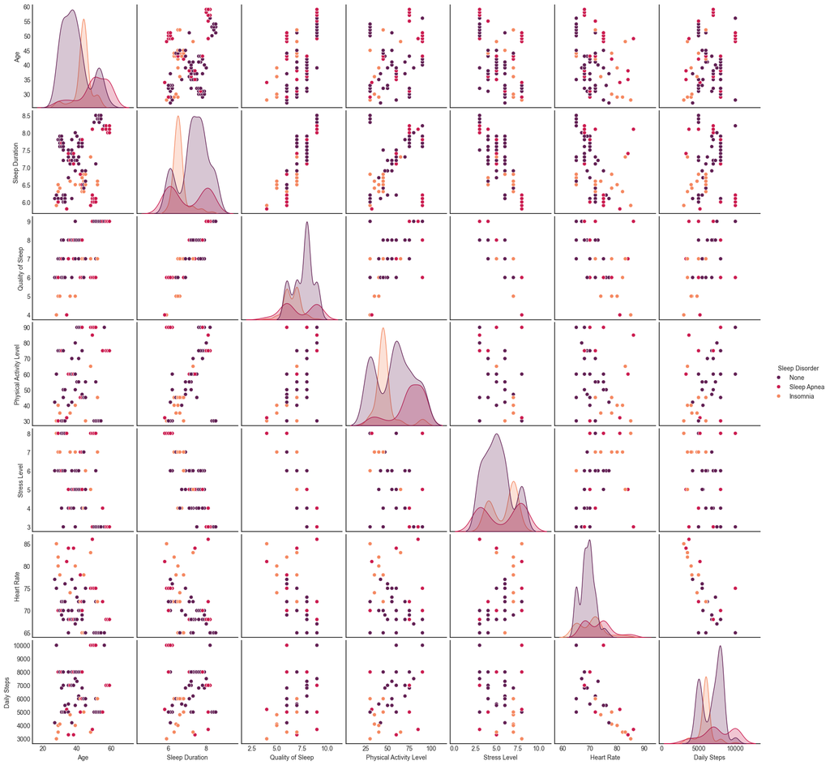

```python
plt.style.use('seaborn-v0_8-white')
sns.pairplot(data=sleep_data.drop('Person ID',axis=1),hue='Sleep Disorder',palette='rocket')

# function add a legend
plt.legend()

# function to show the plot
plt.show()
```

#### Percentage of persons have sleep disorder or not

```python
classes = sleep_data['Sleep Disorder'].unique()
print('The outputs from the classification are :',classes)
```

```
The outputs from the classification are : ['None' 'Sleep Apnea' 'Insomnia']
```

- **Sleep apnea** (โรคหยุดหายใจขณะหลับ) is a potentially serious sleep disorder in which breathing repeatedly stops and starts. If you snore loudly and feel tired even after a full night's sleep, you might have sleep apnea.
- **Insomnia** (โรคนอนไม่หลับ) s a sleep disorder in which you have trouble falling and/or staying asleep. With insomnia, you may have trouble falling asleep, staying asleep, or getting good quality sleep.

```python
sleep_data['Sleep Disorder'].value_counts()
```

```
Sleep Disorder
None           219
Sleep Apnea     78
Insomnia        77
Name: count, dtype: int64
```

#### Observations - Sleep Disorder

- It is clear that the proportion of normal people is more

```python
fig=px.histogram(sleep_data,x='Sleep Disorder',
                 barmode="group",color='Sleep Disorder',
                 color_discrete_sequence=['#aed581', '#f9bdbb','#e84e40'],
                 text_auto=True)


fig.update_layout(title='<b>Distribution of persons have sleep disorder or not</b>..',
                 title_font={'size':25},
                 paper_bgcolor='#fff8f7',
                 plot_bgcolor='#fff8f7',
                 showlegend=True)


fig.update_yaxes(showgrid=False)

fig.show()
```

#### Observations - Sleep Disorder & Sex

- It is clear that **Normal** men more than women
- It is clear that Men who suffer from **Insomnia** more than women
- It is clear that Women who suffer from **Sleep Apnea** more than women

```python
Gender = sleep_data['Gender'].unique()
print('The values of sex column are :', Gender)
```

```
The values of sex column are : ['Male' 'Female']
```

```python
sleep_data.groupby('Sleep Disorder')['Gender'].value_counts()
```

```
Sleep Disorder  Gender
Insomnia        Male       41
                Female     36
None            Male      137
                Female     82
Sleep Apnea     Female     67
                Male       11
Name: count, dtype: int64
```

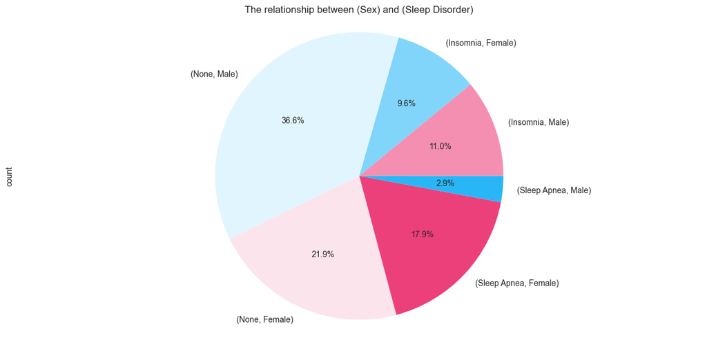

```python
sleep_data.groupby('Sleep Disorder')['Gender'].value_counts().plot.pie(autopct ='%1.1f%%',figsize=(15,7),
                                                                       colors=['#f48fb1','#81d4fa','#e1f5fe','#fce4ec','#ec407a','#29b6f6'])
plt.title('The relationship between (Sex) and (Sleep Disorder)')
plt.axis('equal')
plt.show()
```

#### Observations - Sleep Disorder & Occupation

- It is clear that in **Normal**, **Doctor** more than others
- It is clear that the people who suffer from **Insomnia**, **Salesperson** more than others
- It is clear that the people who suffer from **Sleep Apnea**, **Nurse** more than others

```python
jobs = sleep_data['Occupation'].unique()
print('The types of jobs that exist are :',jobs)
```

```
The types of jobs that exist are : ['Software Engineer' 'Doctor' 'Sales Representative' 'Teacher' 'Nurse'
 'Engineer' 'Accountant' 'Scientist' 'Lawyer' 'Salesperson' 'Manager']
```

```python
sleep_data.groupby('Sleep Disorder')['Occupation'].value_counts()
```

```
Sleep Disorder  Occupation
Insomnia        Salesperson             29
                Teacher                 27
                Accountant               7
                Engineer                 5
                Nurse                    3
                Doctor                   3
                Lawyer                   2
                Software Engineer        1
None            Doctor                  64
                Engineer                57
                Lawyer                  42
                Accountant              30
                Nurse                    9
                Teacher                  9
                Software Engineer        3
                Salesperson              2
                Scientist                2
                Manager                  1
Sleep Apnea     Nurse                   61
                Doctor                   4
                Teacher                  4
                Lawyer                   3
                Sales Representative     2
                Scientist                2
                Engineer                 1
                Salesperson              1
Name: count, dtype: int64
```

```python
fig = px.treemap(sleep_data.dropna(),path=[px.Constant('Jobs'),'Sleep Disorder','Occupation'],
               color='Sleep Disorder',
              color_discrete_sequence=['#e84e40','#aed581','#f9bdbb','#fde0dc'])

fig.update_layout(title='<b>The effect of job on sleep</b>',
                 title_font={'size':20})


fig.show()
```

#### Observations - Sleep Disorder & Quality of Sleep

```python
sleep_data.pivot_table(index='Quality of Sleep',columns='Sleep Disorder',values='Sleep Duration',aggfunc='mean').style.background_gradient(cmap='OrRd')
```

| Sleep Disorder Quality of Sleep | Insomnia | None | Sleep Apnea |
| --- | --- | --- | --- |
| 4 | 5.900000 | nan | 5.850000 |
| 5 | 6.500000 | nan | 6.500000 |
| 6 | 6.371875 | 6.117500 | 6.118182 |
| 7 | 6.638235 | 7.540000 | 7.500000 |
| 8 | 7.520000 | 7.399010 | 7.366667 |
| 9 | 8.300000 | 8.365789 | 8.096875 |

```python
fig=px.sunburst(sleep_data.dropna(),path=[px.Constant('Sleep quality'),'Sleep Disorder','Quality of Sleep'],
               color='Sleep Disorder',values='Sleep Duration',
              color_discrete_sequence=['#aed581','#e84e40','#f9bdbb','#fde0dc'],
              hover_data=['Gender'])

fig.update_layout(title='<b>The effect of quality of sleep on sleep </b>',
                 title_font={'size':25})

fig.show()
```

#### Observations - Sleep Disorder & Physical Activity Level

```python
fig = px.violin(sleep_data, x="Sleep Disorder",y='Physical Activity Level',
                 color='Sleep Disorder',
                 color_discrete_sequence=['#aed581','#e84e40','#f9bdbb'],
                 violinmode='overlay')


fig.update_layout(title='<b>The effect of activities on sleep </b>..',
                 title_font={'size':25},
                 paper_bgcolor='#fff8f7',
                 plot_bgcolor='#fff8f7')

fig.update_yaxes(showgrid=False)
fig.show()
```

#### Observations - Sleep Disorder & Age

- ผญที่อายุมากมีความเสี่ยงมากกว่าผู้ชายอายุมาก

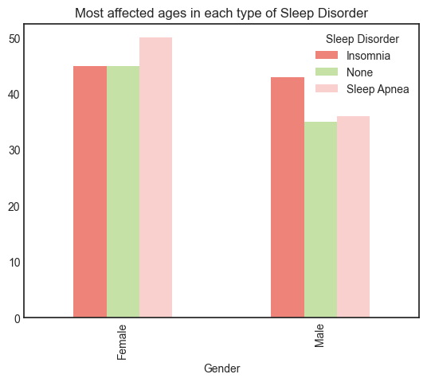

```python
sleep_data.pivot_table(index='Gender',columns='Sleep Disorder',values='Age',aggfunc='median').plot(kind='bar',color=['#e84e40','#aed581','#f9bdbb'],
                                                                                                   title='Most affected ages in each type of Sleep Disorder',
                                                                                                    label='Age',alpha=.7)

plt.show()
```

- risk of Insomnia is higher than Sleep Apnea

```python
fig=px.ecdf(sleep_data,x='Age',
            color='Sleep Disorder',
            color_discrete_sequence=['#aed581','#e84e40','#f9bdbb'])


fig.update_layout(title='<b>The effect of ages on sleep </b>',
                 title_font={'size':25},
                 paper_bgcolor='#fff8f7',
                 plot_bgcolor='#fff8f7')


fig.update_xaxes(showgrid=False)
fig.update_yaxes(showgrid=False)
fig.show()
```

#### Observations - Sleep Disorder & Sleep Duration

- Sleep duration of Sleep Apnea is higheer than Insomnia

```python
fig = px.histogram(sleep_data,x='Sleep Disorder',y='Sleep Duration',
                 color='Sleep Disorder',color_discrete_sequence=['#aed581','#e84e40','#f9bdbb'],
                 text_auto=True)



fig.update_layout(title='<b>The effect of Sleep Duration on Sleep Disorder</b>',
                  titlefont={'size': 24,'family': 'Serif'},
                  showlegend=True,
                  paper_bgcolor='#fff8f7',
                  plot_bgcolor='#fff8f7')



fig.update_yaxes(showgrid=False)




fig.show()
```

#### Observations - Sleep Disorder & BMI Category, Blood Pressure, and Heart Rate

```python
fig=px.scatter_3d(sleep_data,x='BMI Category',y='Blood Pressure',z='Heart Rate',
                  color='Sleep Disorder',width=1000,height=900,
                  color_discrete_sequence=['#aed581','#e84e40','#f9bdbb'])


fig.update_layout(title='<b>The relationship between (BMI Category , Blood Pressure and Heart Rate) and their effect on  Sleep Disorder</b>',
                  titlefont={'size': 20,'family': 'Serif'},
                  showlegend=True)



fig.show()
```

#### Observations - Sleep Disorder & Stress Level

```python
sleep_data.pivot_table(index='Stress Level',columns='Sleep Disorder',aggfunc={'Sleep Disorder':'count'}).style.background_gradient(cmap='OrRd')
```

| Sleep Disorder Stress Level | Sleep Disorder Insomnia | Sleep Disorder None | Sleep Disorder Sleep Apnea |
| --- | --- | --- | --- |
| 3 | 1 | 40 | 30 |
| 4 | 24 | 43 | 3 |
| 5 | 6 | 57 | 4 |
| 6 | 2 | 43 | 1 |
| 7 | 41 | 3 | 6 |
| 8 | 3 | 33 | 34 |

```python
fig=px.histogram(sleep_data,x='Sleep Disorder',
                 color='Sleep Disorder',
                 facet_col='Stress Level',
                 barmode='group',
                 color_discrete_sequence=['#aed581','#e84e40','#f9bdbb'],
                 opacity=.8)


fig.update_layout(title='<b>The effect of Stress Level on Sleep Disorder</b>',title_font={'size':30},
                  paper_bgcolor='#fff8f7',
                  plot_bgcolor='#fff8f7')



fig.update_yaxes(showgrid=False)
fig.show()
```

#### Observations - Sleep Disorder & BMI Category

- overweight people have the highest risk of sleep disorder

```python
BMI_Category = sleep_data['BMI Category'].unique()
print('The values of BMI Category column are :',BMI_Category)
```

```
The values of BMI Category column are : ['Overweight' 'Normal' 'Obese' 'Normal Weight']
```

```python
sleep_data.pivot_table(index='BMI Category',columns='Sleep Disorder',aggfunc={'Sleep Disorder':'count'}).style.background_gradient(cmap='OrRd')
```

| Sleep Disorder BMI Category | Sleep Disorder Insomnia | Sleep Disorder None | Sleep Disorder Sleep Apnea |
| --- | --- | --- | --- |
| Normal | 7.000000 | 183.000000 | 5.000000 |
| Normal Weight | 2.000000 | 17.000000 | 2.000000 |
| Obese | 4.000000 | nan | 6.000000 |
| Overweight | 64.000000 | 19.000000 | 65.000000 |

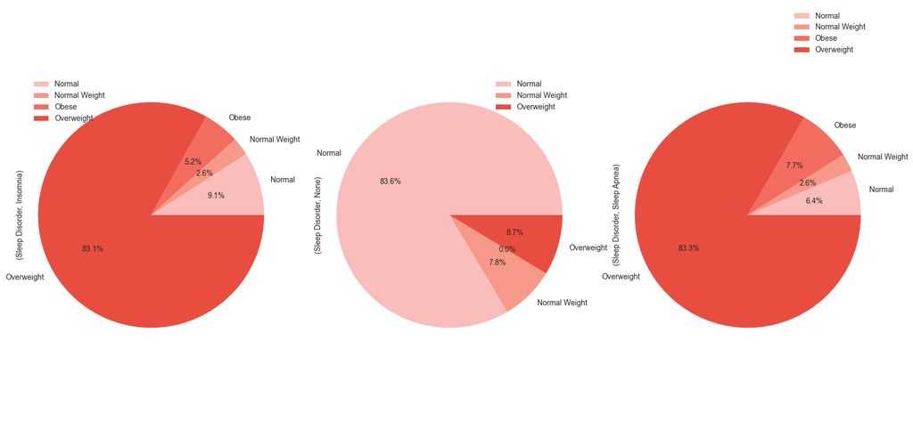

```python
sleep_data.pivot_table(index='BMI Category',columns='Sleep Disorder',aggfunc={'Sleep Disorder':'count'}).plot.pie(autopct ='%1.1f%%',
                                                                                                                  subplots=True,figsize=(20,10),
                                                                                                                  colors=['#f9bdbb','#f69988','#f36c60','#e84e40'])

plt.axis('equal')
plt.show()
```

### 5. Data preprocessing

- **Data preprocessing** refers to the technique of preparing (cleaning and organizing) the raw data to make it suitable for a building and training Machine Learning models.

#### Finding and cleaning aull values

- There is no null values

```python
# checking null

sleep_data.isna().sum()
```

```
Person ID                  0
Gender                     0
Age                        0
Occupation                 0
Sleep Duration             0
Quality of Sleep           0
Physical Activity Level    0
Stress Level               0
BMI Category               0
Blood Pressure             0
Heart Rate                 0
Daily Steps                0
Sleep Disorder             0
dtype: int64
```

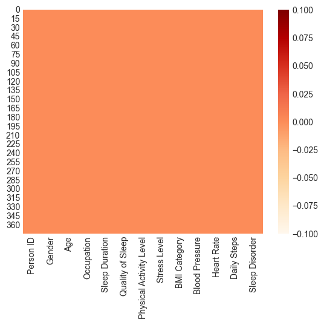

```python
sns.heatmap(sleep_data.isna(),cmap='OrRd')
```

#### Data Encoding

- turning all value into number

```python
sleep_data.columns
```

```
Index(['Person ID', 'Gender', 'Age', 'Occupation', 'Sleep Duration',
       'Quality of Sleep', 'Physical Activity Level', 'Stress Level',
       'BMI Category', 'Blood Pressure', 'Heart Rate', 'Daily Steps',
       'Sleep Disorder'],
      dtype='object')
```

```python
sleep_data['Blood Pressure'].unique()
```

```
array(['126/83', '125/80', '140/90', '120/80', '132/87', '130/86',
       '117/76', '118/76', '128/85', '131/86', '128/84', '115/75',
       '135/88', '129/84', '130/85', '115/78', '119/77', '121/79',
       '125/82', '135/90', '122/80', '142/92', '140/95', '139/91',
       '118/75'], dtype=object)
```

**Note**

```python
sleep_table = sleep_data.copy()
sleep_table['Blood Pressure'] = sleep_table['Blood Pressure'].apply(lambda x:0 if x in ['120/80','126/83','125/80','128/84','129/84','117/76','118/76','115/75','125/82','122/80'] else 1)
# 0 = normal blood pressure
# 1 = abnormal blood pressure

sleep_table
```

|  | Person ID | Gender | Age | Occupation | Sleep Duration | Quality of Sleep | Physical Activity Level | Stress Level | BMI Category | Blood Pressure | Heart Rate | Daily Steps | Sleep Disorder |
| --- | --- | --- | --- | --- | --- | --- | --- | --- | --- | --- | --- | --- | --- |
| 0 | 1 | Male | 27 | Software Engineer | 6.1 | 6 | 42 | 6 | Overweight | 0 | 77 | 4200 | None |
| 1 | 2 | Male | 28 | Doctor | 6.2 | 6 | 60 | 8 | Normal | 0 | 75 | 10000 | None |
| 2 | 3 | Male | 28 | Doctor | 6.2 | 6 | 60 | 8 | Normal | 0 | 75 | 10000 | None |
| 3 | 4 | Male | 28 | Sales Representative | 5.9 | 4 | 30 | 8 | Obese | 1 | 85 | 3000 | Sleep Apnea |
| 4 | 5 | Male | 28 | Sales Representative | 5.9 | 4 | 30 | 8 | Obese | 1 | 85 | 3000 | Sleep Apnea |
| ... | ... | ... | ... | ... | ... | ... | ... | ... | ... | ... | ... | ... | ... |
| 369 | 370 | Female | 59 | Nurse | 8.1 | 9 | 75 | 3 | Overweight | 1 | 68 | 7000 | Sleep Apnea |
| 370 | 371 | Female | 59 | Nurse | 8.0 | 9 | 75 | 3 | Overweight | 1 | 68 | 7000 | Sleep Apnea |
| 371 | 372 | Female | 59 | Nurse | 8.1 | 9 | 75 | 3 | Overweight | 1 | 68 | 7000 | Sleep Apnea |
| 372 | 373 | Female | 59 | Nurse | 8.1 | 9 | 75 | 3 | Overweight | 1 | 68 | 7000 | Sleep Apnea |
| 373 | 374 | Female | 59 | Nurse | 8.1 | 9 | 75 | 3 | Overweight | 1 | 68 | 7000 | Sleep Apnea |

374 rows × 13 columns

```python
sleep_table["Age"] = pd.cut(sleep_table["Age"],2)
sleep_table["Heart Rate"] = pd.cut(sleep_table["Heart Rate"],4)
sleep_table["Daily Steps"] = pd.cut(sleep_table["Daily Steps"],4)
sleep_table["Sleep Duration"] = pd.cut(sleep_table["Sleep Duration"],3)
sleep_table["Physical Activity Level"] = pd.cut(sleep_table["Physical Activity Level"],4)

sleep_table
```

|  | Person ID | Gender | Age | Occupation | Sleep Duration | Quality of Sleep | Physical Activity Level | Stress Level | BMI Category | Blood Pressure | Heart Rate | Daily Steps | Sleep Disorder |
| --- | --- | --- | --- | --- | --- | --- | --- | --- | --- | --- | --- | --- | --- |
| 0 | 1 | Male | (26.968, 43.0] | Software Engineer | (5.797, 6.7] | 6 | (29.94, 45.0] | 6 | Overweight | 0 | (75.5, 80.75] | (2993.0, 4750.0] | None |
| 1 | 2 | Male | (26.968, 43.0] | Doctor | (5.797, 6.7] | 6 | (45.0, 60.0] | 8 | Normal | 0 | (70.25, 75.5] | (8250.0, 10000.0] | None |
| 2 | 3 | Male | (26.968, 43.0] | Doctor | (5.797, 6.7] | 6 | (45.0, 60.0] | 8 | Normal | 0 | (70.25, 75.5] | (8250.0, 10000.0] | None |
| 3 | 4 | Male | (26.968, 43.0] | Sales Representative | (5.797, 6.7] | 4 | (29.94, 45.0] | 8 | Obese | 1 | (80.75, 86.0] | (2993.0, 4750.0] | Sleep Apnea |
| 4 | 5 | Male | (26.968, 43.0] | Sales Representative | (5.797, 6.7] | 4 | (29.94, 45.0] | 8 | Obese | 1 | (80.75, 86.0] | (2993.0, 4750.0] | Sleep Apnea |
| ... | ... | ... | ... | ... | ... | ... | ... | ... | ... | ... | ... | ... | ... |
| 369 | 370 | Female | (43.0, 59.0] | Nurse | (7.6, 8.5] | 9 | (60.0, 75.0] | 3 | Overweight | 1 | (64.979, 70.25] | (6500.0, 8250.0] | Sleep Apnea |
| 370 | 371 | Female | (43.0, 59.0] | Nurse | (7.6, 8.5] | 9 | (60.0, 75.0] | 3 | Overweight | 1 | (64.979, 70.25] | (6500.0, 8250.0] | Sleep Apnea |
| 371 | 372 | Female | (43.0, 59.0] | Nurse | (7.6, 8.5] | 9 | (60.0, 75.0] | 3 | Overweight | 1 | (64.979, 70.25] | (6500.0, 8250.0] | Sleep Apnea |
| 372 | 373 | Female | (43.0, 59.0] | Nurse | (7.6, 8.5] | 9 | (60.0, 75.0] | 3 | Overweight | 1 | (64.979, 70.25] | (6500.0, 8250.0] | Sleep Apnea |
| 373 | 374 | Female | (43.0, 59.0] | Nurse | (7.6, 8.5] | 9 | (60.0, 75.0] | 3 | Overweight | 1 | (64.979, 70.25] | (6500.0, 8250.0] | Sleep Apnea |

374 rows × 13 columns

```python
# converting non-numeric data (String or Boolean) into numbers

LE = LabelEncoder()

categories = ['Gender','Age','Occupation','Sleep Duration','Physical Activity Level','BMI Category','Heart Rate','Daily Steps','Sleep Disorder']
for label in categories:
    sleep_table[label] = LE.fit_transform(sleep_table[label])

sleep_table
```

|  | Person ID | Gender | Age | Occupation | Sleep Duration | Quality of Sleep | Physical Activity Level | Stress Level | BMI Category | Blood Pressure | Heart Rate | Daily Steps | Sleep Disorder |
| --- | --- | --- | --- | --- | --- | --- | --- | --- | --- | --- | --- | --- | --- |
| 0 | 1 | 1 | 0 | 9 | 0 | 6 | 0 | 6 | 3 | 0 | 2 | 0 | 1 |
| 1 | 2 | 1 | 0 | 1 | 0 | 6 | 1 | 8 | 0 | 0 | 1 | 3 | 1 |
| 2 | 3 | 1 | 0 | 1 | 0 | 6 | 1 | 8 | 0 | 0 | 1 | 3 | 1 |
| 3 | 4 | 1 | 0 | 6 | 0 | 4 | 0 | 8 | 2 | 1 | 3 | 0 | 2 |
| 4 | 5 | 1 | 0 | 6 | 0 | 4 | 0 | 8 | 2 | 1 | 3 | 0 | 2 |
| ... | ... | ... | ... | ... | ... | ... | ... | ... | ... | ... | ... | ... | ... |
| 369 | 370 | 0 | 1 | 5 | 2 | 9 | 2 | 3 | 3 | 1 | 0 | 2 | 2 |
| 370 | 371 | 0 | 1 | 5 | 2 | 9 | 2 | 3 | 3 | 1 | 0 | 2 | 2 |
| 371 | 372 | 0 | 1 | 5 | 2 | 9 | 2 | 3 | 3 | 1 | 0 | 2 | 2 |
| 372 | 373 | 0 | 1 | 5 | 2 | 9 | 2 | 3 | 3 | 1 | 0 | 2 | 2 |
| 373 | 374 | 0 | 1 | 5 | 2 | 9 | 2 | 3 | 3 | 1 | 0 | 2 | 2 |

374 rows × 13 columns

```python
# drop ID column

sleep_table.drop(['Person ID'], axis=1, inplace=True)
```

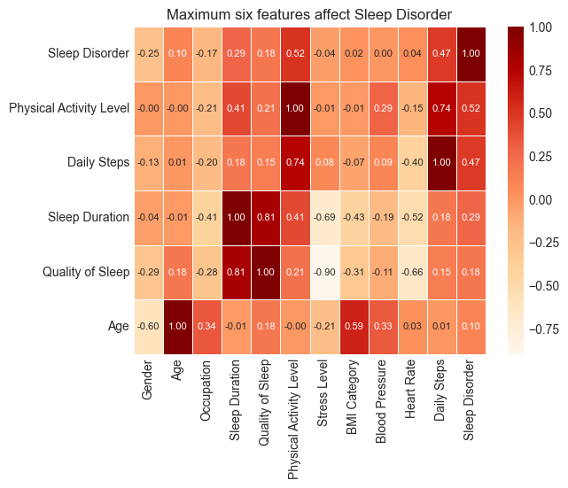

```python
correlation = sleep_table.corr()
max_6_corr = correlation.nlargest(6,"Sleep Disorder")
sns.heatmap(max_6_corr,annot=True,fmt=".2F",annot_kws={"size":8},linewidths=0.5,cmap='OrRd')
plt.title('Maximum six features affect Sleep Disorder')
plt.show()
```

#### Data Spliting

```python
x = sleep_table.iloc[:,:-1] # all rows, all columns except the last one
y = sleep_table.iloc[:,-1] # all rows, only the last column

x_shape = x.shape
y_shape = y.shape
print('The dimensions of x is : ',x_shape)
print('The dimensions of y is : ',y_shape)
```

```
The dimensions of x is :  (374, 11)
The dimensions of y is :  (374,)
```

```python
x_train, x_test, y_train, y_test = train_test_split(x, y, test_size=.33, random_state=32, shuffle=True)
```

```python
x_train_shape=  x_train.shape
x_test_shape = x_test.shape
y_train_shape = y_train.shape
y_test_shape = y_test.shape

print("x train dimensions :",x_train_shape)
print("x test dimensions: ",x_test_shape)
print("y train dimensions :",y_train_shape)
print("y test dimensions :",y_test_shape)
```

```
x train dimensions : (250, 11)
x test dimensions:  (124, 11)
y train dimensions : (250,)
y test dimensions : (124,)
```

```python
x_train
```

|  | Gender | Age | Occupation | Sleep Duration | Quality of Sleep | Physical Activity Level | Stress Level | BMI Category | Blood Pressure | Heart Rate | Daily Steps |
| --- | --- | --- | --- | --- | --- | --- | --- | --- | --- | --- | --- |
| 17 | 1 | 0 | 1 | 0 | 6 | 0 | 8 | 0 | 0 | 0 | 2 |
| 160 | 1 | 0 | 3 | 1 | 8 | 1 | 5 | 0 | 1 | 0 | 2 |
| 115 | 0 | 0 | 0 | 1 | 8 | 1 | 4 | 0 | 0 | 0 | 2 |
| 260 | 0 | 1 | 10 | 0 | 7 | 0 | 4 | 3 | 1 | 0 | 1 |
| 8 | 1 | 0 | 1 | 2 | 7 | 2 | 6 | 0 | 0 | 0 | 2 |
| ... | ... | ... | ... | ... | ... | ... | ... | ... | ... | ... | ... |
| 252 | 0 | 1 | 10 | 0 | 7 | 0 | 4 | 3 | 1 | 0 | 1 |
| 88 | 1 | 0 | 2 | 1 | 8 | 1 | 4 | 0 | 0 | 0 | 1 |
| 310 | 0 | 1 | 0 | 0 | 7 | 0 | 7 | 3 | 1 | 1 | 1 |
| 43 | 1 | 0 | 1 | 2 | 7 | 2 | 6 | 0 | 0 | 0 | 2 |
| 215 | 1 | 0 | 2 | 2 | 8 | 3 | 5 | 0 | 1 | 0 | 2 |

250 rows × 11 columns

```python
x_test
```

|  | Gender | Age | Occupation | Sleep Duration | Quality of Sleep | Physical Activity Level | Stress Level | BMI Category | Blood Pressure | Heart Rate | Daily Steps |
| --- | --- | --- | --- | --- | --- | --- | --- | --- | --- | --- | --- |
| 107 | 1 | 0 | 2 | 2 | 8 | 2 | 4 | 1 | 0 | 0 | 2 |
| 56 | 1 | 0 | 1 | 2 | 7 | 2 | 6 | 0 | 0 | 0 | 2 |
| 358 | 0 | 1 | 5 | 2 | 9 | 2 | 3 | 3 | 1 | 0 | 2 |
| 60 | 1 | 0 | 1 | 0 | 6 | 0 | 8 | 0 | 0 | 1 | 1 |
| 271 | 0 | 1 | 5 | 0 | 6 | 3 | 8 | 3 | 1 | 1 | 3 |
| ... | ... | ... | ... | ... | ... | ... | ... | ... | ... | ... | ... |
| 282 | 0 | 1 | 5 | 0 | 6 | 3 | 8 | 3 | 1 | 1 | 3 |
| 291 | 0 | 1 | 5 | 0 | 6 | 3 | 8 | 3 | 1 | 1 | 3 |
| 289 | 0 | 1 | 5 | 0 | 6 | 3 | 8 | 3 | 1 | 1 | 3 |
| 238 | 1 | 1 | 7 | 0 | 6 | 0 | 7 | 3 | 1 | 1 | 1 |
| 348 | 0 | 1 | 5 | 2 | 9 | 2 | 3 | 3 | 1 | 0 | 2 |

124 rows × 11 columns

### 6. Data Modeling

#### 6.1 LogisticRegression Model

```python
# LogisticRegression for Data Modeling
from sklearn.linear_model import LogisticRegression

LR = LogisticRegression().fit(x_train,y_train)
```

```python
LR_training_score = round(LR.score(x_train,y_train)*100,2)
LR_testing_score = round(LR.score(x_test,y_test)*100,2)

print(f"LR training score :",LR_training_score)
print("LR testing score :",LR_testing_score)
```

```
LR training score : 90.8
LR testing score : 91.94
```

```python
LR_y_pred = LR.predict(x_test)
```

#### 6.2 XGBClassifier Model

```python
import xgboost
from xgboost import XGBClassifier
xgb = xgboost.XGBClassifier()
xgb.fit(x_train,y_train)
```

```
XGBClassifier(base_score=None, booster=None, callbacks=None,
              colsample_bylevel=None, colsample_bynode=None,
              colsample_bytree=None, device=None, early_stopping_rounds=None,
              enable_categorical=False, eval_metric=None, feature_types=None,
              gamma=None, grow_policy=None, importance_type=None,
              interaction_constraints=None, learning_rate=None, max_bin=None,
              max_cat_threshold=None, max_cat_to_onehot=None,
              max_delta_step=None, max_depth=None, max_leaves=None,
              min_child_weight=None, missing=nan, monotone_constraints=None,
              multi_strategy=None, n_estimators=None, n_jobs=None,
              num_parallel_tree=None, objective='multi:softprob', ...)
```

```python
xgb_training_score = round(xgb.score(x_train,y_train)*100,2)
xgb_testing_score = round(xgb.score(x_test,y_test)*100,2)
print("xgb training score :",xgb_training_score)
print("xgb testing score :",xgb_testing_score)
```

```
xgb training score : 93.2
xgb testing score : 91.13
```

```python
xgb_y_pred = xgb.predict(x_test)
```

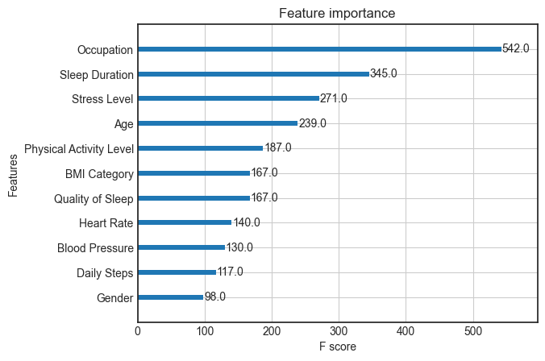

```python
xgboost.plot_importance(xgb)
```

#### 6.3 CatBoostClassifier Model

```python
from catboost import CatBoostClassifier
CBC = CatBoostClassifier(verbose=False).fit(x_train,y_train)
```

```python
CBC_training_score = round(CBC.score(x_train,y_train)*100,2)
CBC_testing_score = round(CBC.score(x_test,y_test)*100,2)

print("CBC training score :",CBC_training_score)
print("CBC testing score :",CBC_testing_score)
```

```
CBC training score : 93.2
CBC testing score : 91.13
```

```python
CBC_y_pred = CBC.predict(x_test)
```

#### 6.4 GradientBoostingClassifier Model

```python
from sklearn.ensemble import GradientBoostingClassifier
GBC = GradientBoostingClassifier().fit(x_train,y_train)
```

```python
GBC_training_score = round(GBC.score(x_train,y_train)*100,2)
GBC_testing_score = round(GBC.score(x_test,y_test)*100,2)

print("GBC training score :",GBC_training_score)
print("GBC testing score :",GBC_testing_score)
```

```
GBC training score : 93.2
GBC testing score : 91.13
```

```python
GBC_y_pred = GBC.predict(x_test)
```

#### 6.5 SVC Model

```python
from sklearn.svm import SVC
svc = SVC().fit(x_train,y_train)
```

```python
svc_training_score = round(svc.score(x_train,y_train)*100,2)
svc_testing_score = round(svc.score(x_test,y_test)*100,2)

print("svc training score :",svc_training_score)
print("svc testing score :",svc_testing_score)
```

```
svc training score : 88.8
svc testing score : 87.9
```

```python
svc_y_pred = svc.predict(x_test)
```

### 7. Models Evaluation

[figure not shown]

```python
from sklearn.metrics import confusion_matrix

models_predictions = [LR_y_pred,xgb_y_pred,CBC_y_pred,GBC_y_pred,svc_y_pred]
model = {1:'LR_y_pred',2:'xgb_y_pred',3:'CBC_y_pred',4:'GBC_y_pred',5:'svc_y_pred'}


plt.figure(figsize=(15,7))
for i,y_pred in enumerate(models_predictions,1) :

    cm = confusion_matrix(y_pred,y_test)

    plt.subplot(2,3,i)
    sns.heatmap(cm,cmap='BuPu',linewidth=3,fmt='',annot=True,
                xticklabels=['(None)','(Sleep_Apnea)','(Insomnia)'],
                yticklabels=['(None)','(Sleep_Apnea)','(Insomnia)'])


    plt.title(' CM of  '+ model[i])
    plt.xlabel('Predicted Label')
    plt.ylabel('True Label')
    plt.subplots_adjust(hspace=0.5,wspace=0.5)
```

### 8. Interpretation one model

- XGBClassifier Model

```
PermutationExplainer explainer: 125it [00:36,  2.40it/s]
```

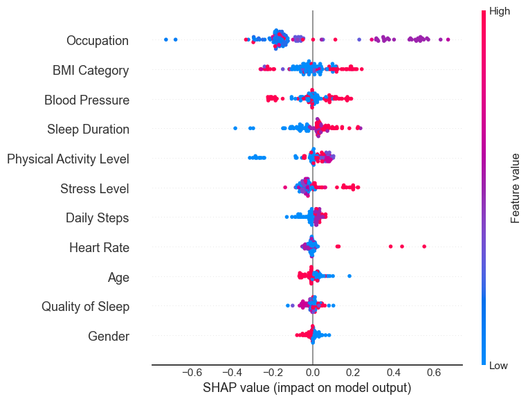

```python
import shap

explainer = shap.Explainer(xgb.predict, x_test)
shap_values = explainer(x_test)
shap.summary_plot(shap_values, x_test,class_names=['None','Sleep_Apnea','Insomnia'])
```

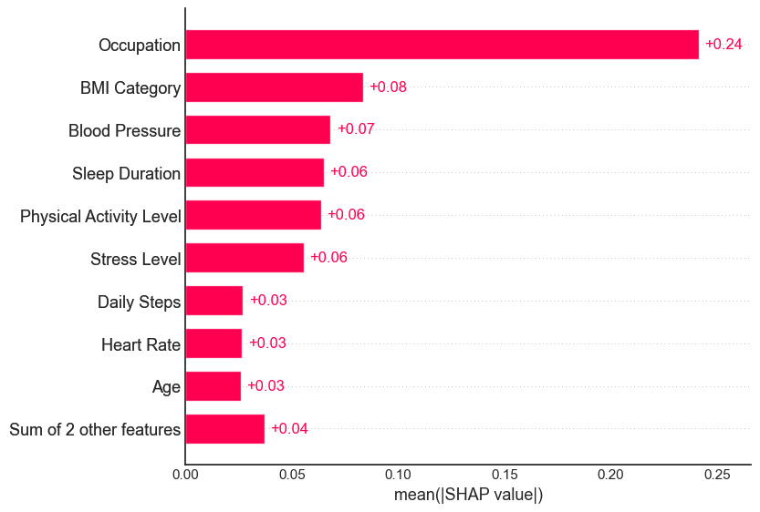

```python
shap.plots.bar(shap_values)
```

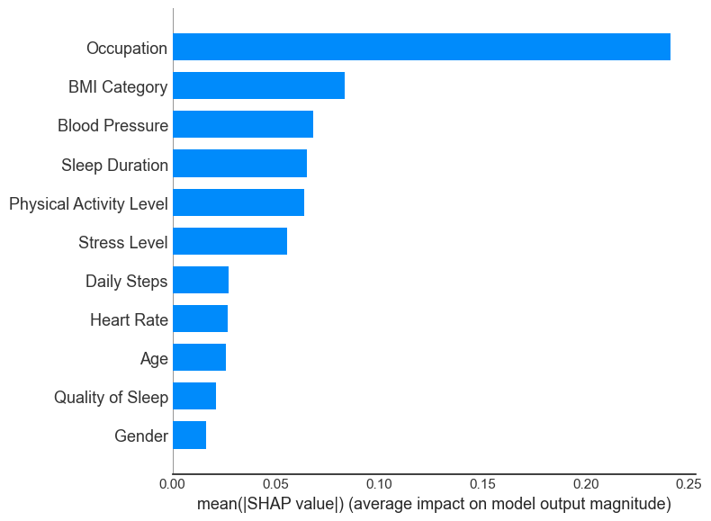

```python
shap.summary_plot(shap_values, x_test,class_names=['None','Sleep_Apnea','Insomnia'],plot_type='bar')
```